# Risk Factor Analysis

## Outcome Variable

**Outcome Variable:** haz

## Predictor Variables

**Intervention Variable:** mhtcm

**Adjustment Set:**

- arm
- W_mage
- meducyrs
- feducyrs
- single
- impsan
- W_gagebrth
- W_birthwt
- W_birthlen
- vagbrth
- parity
- delta_W_mage
- delta_meducyrs
- delta_feducyrs
- delta_single
- delta_impsan
- delta_W_gagebrth
- delta_W_birthwt
- delta_W_birthlen
- delta_vagbrth
- delta_parity

## Stratifying Variables

The analysis was stratified on these variable(s):

- agecat
- studyid
- country

## Data Summary

| agecat | studyid | country | mhtcm | n_cell | n |
| --- | --- | --- | --- | --- | --- |
| 6 months | ki0047075b-MAL-ED | BANGLADESH | >=155 cm | 24 | 241 |
| 6 months | ki0047075b-MAL-ED | BANGLADESH | <151 cm | 156 | 241 |
| 6 months | ki0047075b-MAL-ED | BANGLADESH | [151-155) cm | 61 | 241 |
| 6 months | ki0047075b-MAL-ED | BRAZIL | >=155 cm | 121 | 209 |
| 6 months | ki0047075b-MAL-ED | BRAZIL | <151 cm | 51 | 209 |
| 6 months | ki0047075b-MAL-ED | BRAZIL | [151-155) cm | 37 | 209 |
| 6 months | ki0047075b-MAL-ED | INDIA | >=155 cm | 55 | 235 |
| 6 months | ki0047075b-MAL-ED | INDIA | <151 cm | 112 | 235 |
| 6 months | ki0047075b-MAL-ED | INDIA | [151-155) cm | 68 | 235 |
| 6 months | ki0047075b-MAL-ED | NEPAL | >=155 cm | 41 | 236 |
| 6 months | ki0047075b-MAL-ED | NEPAL | <151 cm | 132 | 236 |
| 6 months | ki0047075b-MAL-ED | NEPAL | [151-155) cm | 63 | 236 |
| 6 months | ki0047075b-MAL-ED | PERU | >=155 cm | 58 | 272 |
| 6 months | ki0047075b-MAL-ED | PERU | <151 cm | 157 | 272 |
| 6 months | ki0047075b-MAL-ED | PERU | [151-155) cm | 57 | 272 |
| 6 months | ki0047075b-MAL-ED | SOUTH AFRICA | >=155 cm | 187 | 249 |
| 6 months | ki0047075b-MAL-ED | SOUTH AFRICA | <151 cm | 31 | 249 |
| 6 months | ki0047075b-MAL-ED | SOUTH AFRICA | [151-155) cm | 31 | 249 |
| 6 months | ki0047075b-MAL-ED | TANZANIA, UNITED REPUBLIC OF | >=155 cm | 147 | 247 |
| 6 months | ki0047075b-MAL-ED | TANZANIA, UNITED REPUBLIC OF | <151 cm | 48 | 247 |
| 6 months | ki0047075b-MAL-ED | TANZANIA, UNITED REPUBLIC OF | [151-155) cm | 52 | 247 |
| 6 months | ki1000304b-SAS-CompFeed | INDIA | >=155 cm | 510 | 1228 |
| 6 months | ki1000304b-SAS-CompFeed | INDIA | <151 cm | 421 | 1228 |
| 6 months | ki1000304b-SAS-CompFeed | INDIA | [151-155) cm | 297 | 1228 |
| 6 months | ki1000304b-SAS-FoodSuppl | INDIA | >=155 cm | 74 | 379 |
| 6 months | ki1000304b-SAS-FoodSuppl | INDIA | <151 cm | 202 | 379 |
| 6 months | ki1000304b-SAS-FoodSuppl | INDIA | [151-155) cm | 103 | 379 |
| 6 months | ki1017093-NIH-Birth | BANGLADESH | >=155 cm | 96 | 537 |
| 6 months | ki1017093-NIH-Birth | BANGLADESH | <151 cm | 311 | 537 |
| 6 months | ki1017093-NIH-Birth | BANGLADESH | [151-155) cm | 130 | 537 |

[output cut: 93 more lines]

The following strata were considered:

- agecat: 24 months, studyid: ki0047075b-MAL-ED, country: BANGLADESH
- agecat: 24 months, studyid: ki0047075b-MAL-ED, country: BRAZIL
- agecat: 24 months, studyid: ki0047075b-MAL-ED, country: INDIA
- agecat: 24 months, studyid: ki0047075b-MAL-ED, country: NEPAL
- agecat: 24 months, studyid: ki0047075b-MAL-ED, country: PERU
- agecat: 24 months, studyid: ki0047075b-MAL-ED, country: SOUTH AFRICA
- agecat: 24 months, studyid: ki0047075b-MAL-ED, country: TANZANIA, UNITED REPUBLIC OF
- agecat: 24 months, studyid: ki1017093-NIH-Birth, country: BANGLADESH
- agecat: 24 months, studyid: ki1017093b-PROVIDE, country: BANGLADESH
- agecat: 24 months, studyid: ki1017093c-NIH-Crypto, country: BANGLADESH
- agecat: 24 months, studyid: ki1066203-TanzaniaChild2, country: TANZANIA, UNITED REPUBLIC OF
- agecat: 24 months, studyid: ki1101329-Keneba, country: GAMBIA
- agecat: 24 months, studyid: ki1119695-PROBIT, country: BELARUS
- agecat: 24 months, studyid: ki1126311-ZVITAMBO, country: ZIMBABWE
- agecat: 24 months, studyid: ki1135781-COHORTS, country: GUATEMALA
- agecat: 24 months, studyid: ki1135781-COHORTS, country: INDIA
- agecat: 24 months, studyid: ki1135781-COHORTS, country: PHILIPPINES
- agecat: 24 months, studyid: ki1148112-LCNI-5, country: MALAWI
- agecat: 24 months, studyid: kiGH5241-JiVitA-3, country: BANGLADESH
- agecat: 6 months, studyid: ki0047075b-MAL-ED, country: BANGLADESH
- agecat: 6 months, studyid: ki0047075b-MAL-ED, country: BRAZIL
- agecat: 6 months, studyid: ki0047075b-MAL-ED, country: INDIA
- agecat: 6 months, studyid: ki0047075b-MAL-ED, country: NEPAL
- agecat: 6 months, studyid: ki0047075b-MAL-ED, country: PERU
- agecat: 6 months, studyid: ki0047075b-MAL-ED, country: SOUTH AFRICA
- agecat: 6 months, studyid: ki0047075b-MAL-ED, country: TANZANIA, UNITED REPUBLIC OF
- agecat: 6 months, studyid: ki1000304b-SAS-CompFeed, country: INDIA
- agecat: 6 months, studyid: ki1000304b-SAS-FoodSuppl, country: INDIA
- agecat: 6 months, studyid: ki1017093-NIH-Birth, country: BANGLADESH
- agecat: 6 months, studyid: ki1017093b-PROVIDE, country: BANGLADESH
- agecat: 6 months, studyid: ki1017093c-NIH-Crypto, country: BANGLADESH
- agecat: 6 months, studyid: ki1066203-TanzaniaChild2, country: TANZANIA, UNITED REPUBLIC OF
- agecat: 6 months, studyid: ki1101329-Keneba, country: GAMBIA
- agecat: 6 months, studyid: ki1112895-Guatemala BSC, country: GUATEMALA
- agecat: 6 months, studyid: ki1119695-PROBIT, country: BELARUS
- agecat: 6 months, studyid: ki1126311-ZVITAMBO, country: ZIMBABWE
- agecat: 6 months, studyid: ki1135781-COHORTS, country: GUATEMALA
- agecat: 6 months, studyid: ki1135781-COHORTS, country: INDIA
- agecat: 6 months, studyid: ki1135781-COHORTS, country: PHILIPPINES
- agecat: 6 months, studyid: ki1148112-LCNI-5, country: MALAWI
- agecat: 6 months, studyid: kiGH5241-JiVitA-3, country: BANGLADESH

### Dropped Strata

Some strata were dropped due to rare outcomes:

- agecat: 24 months, studyid: ki1066203-TanzaniaChild2, country: TANZANIA, UNITED REPUBLIC OF

## Methods Detail

We’re interested in the causal parameters $E[Y_a]$ for all values of $a \in \mathcal{A}$. These parameters represent the mean outcome if, possibly contrary to fact, we intervened to set all units to have $A=a$. Under the randomization and positivity assumptions, these are identified by the statistical parameters $\psi_a=E_W[E_{Y|A,W}(Y|A=a,W)]$. In addition, we’re interested in the mean of $Y$, $E[Y]$ under no intervention (the observed mean). We will estimate these parameters by using SuperLearner to fit the relevant likelihood factors – $E_{Y|A,W}(Y|A=a,W)$ and $p(A=a|W)$, and then updating our likelihood fit using a joint TMLE.

For unadjusted analyses ($W=\{\}$), initial likelihoods were estimated using Lrnr_glm to estimate the simple $E(Y|A)$ and Lrnr_mean to estimate $p(A)$. For adjusted analyses, a small library containing Lrnr_glmnet, Lrnr_xgboost, and Lrnr_mean was used.

Having estimated these parameters, we will then use the delta method to estimate relative risks and attributable risks relative to a prespecified baseline level of $A$.

# Results Detail

## Results Plots

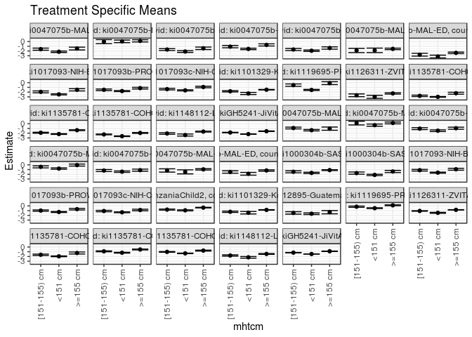

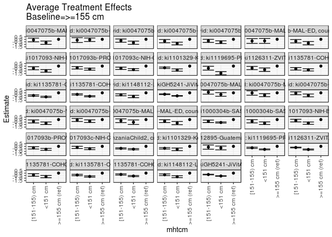

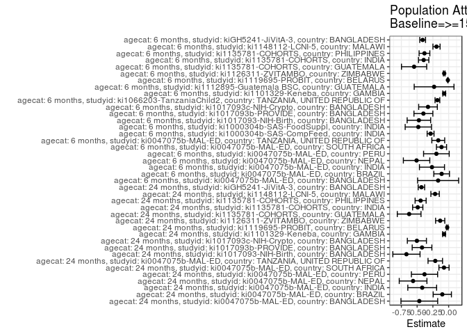

## Results Table

### Parameter: TSM

| agecat | studyid | country | intervention_level | baseline_level | estimate | ci_lower | ci_upper |
| --- | --- | --- | --- | --- | --- | --- | --- |
| 6 months | ki0047075b-MAL-ED | BANGLADESH | >=155 cm | NA | -1.0385718 | -1.3729718 | -0.7041717 |
| 6 months | ki0047075b-MAL-ED | BANGLADESH | <151 cm | NA | -1.3667518 | -1.5189715 | -1.2145320 |
| 6 months | ki0047075b-MAL-ED | BANGLADESH | [151-155) cm | NA | -0.9121243 | -1.1011807 | -0.7230678 |
| 6 months | ki0047075b-MAL-ED | BRAZIL | >=155 cm | NA | 0.1622629 | -0.0282142 | 0.3527399 |
| 6 months | ki0047075b-MAL-ED | BRAZIL | <151 cm | NA | -0.3014439 | -0.5310116 | -0.0718762 |
| 6 months | ki0047075b-MAL-ED | BRAZIL | [151-155) cm | NA | 0.1331742 | -0.2577704 | 0.5241188 |
| 6 months | ki0047075b-MAL-ED | INDIA | >=155 cm | NA | -0.9501104 | -1.1678484 | -0.7323724 |
| 6 months | ki0047075b-MAL-ED | INDIA | <151 cm | NA | -1.4713687 | -1.6486777 | -1.2940597 |
| 6 months | ki0047075b-MAL-ED | INDIA | [151-155) cm | NA | -1.0341242 | -1.2340961 | -0.8341523 |
| 6 months | ki0047075b-MAL-ED | NEPAL | >=155 cm | NA | -0.0522812 | -0.2685773 | 0.1640149 |
| 6 months | ki0047075b-MAL-ED | NEPAL | <151 cm | NA | -0.7922998 | -0.9397745 | -0.6448251 |
| 6 months | ki0047075b-MAL-ED | NEPAL | [151-155) cm | NA | -0.4281176 | -0.6431667 | -0.2130684 |
| 6 months | ki0047075b-MAL-ED | PERU | >=155 cm | NA | -1.1327596 | -1.3509228 | -0.9145965 |
| 6 months | ki0047075b-MAL-ED | PERU | <151 cm | NA | -1.4475156 | -1.5966421 | -1.2983891 |
| 6 months | ki0047075b-MAL-ED | PERU | [151-155) cm | NA | -1.2106986 | -1.4268760 | -0.9945212 |
| 6 months | ki0047075b-MAL-ED | SOUTH AFRICA | >=155 cm | NA | -0.9594399 | -1.1054752 | -0.8134046 |
| 6 months | ki0047075b-MAL-ED | SOUTH AFRICA | <151 cm | NA | -1.4882957 | -1.9152957 | -1.0612956 |
| 6 months | ki0047075b-MAL-ED | SOUTH AFRICA | [151-155) cm | NA | -1.1898925 | -1.5399080 | -0.8398771 |
| 6 months | ki0047075b-MAL-ED | TANZANIA, UNITED REPUBLIC OF | >=155 cm | NA | -1.1951801 | -1.3428754 | -1.0474848 |
| 6 months | ki0047075b-MAL-ED | TANZANIA, UNITED REPUBLIC OF | <151 cm | NA | -1.8945936 | -2.1855132 | -1.6036740 |
| 6 months | ki0047075b-MAL-ED | TANZANIA, UNITED REPUBLIC OF | [151-155) cm | NA | -1.5118471 | -1.7598380 | -1.2638563 |
| 6 months | ki1000304b-SAS-CompFeed | INDIA | >=155 cm | NA | -1.1202462 | -1.2081917 | -1.0323007 |
| 6 months | ki1000304b-SAS-CompFeed | INDIA | <151 cm | NA | -1.7067530 | -1.8465093 | -1.5669966 |
| 6 months | ki1000304b-SAS-CompFeed | INDIA | [151-155) cm | NA | -1.4721145 | -1.6824905 | -1.2617385 |
| 6 months | ki1000304b-SAS-FoodSuppl | INDIA | >=155 cm | NA | -1.4071796 | -1.6317302 | -1.1826291 |
| 6 months | ki1000304b-SAS-FoodSuppl | INDIA | <151 cm | NA | -2.1346175 | -2.2785749 | -1.9906600 |
| 6 months | ki1000304b-SAS-FoodSuppl | INDIA | [151-155) cm | NA | -1.7470043 | -1.9773861 | -1.5166226 |
| 6 months | ki1017093-NIH-Birth | BANGLADESH | >=155 cm | NA | -0.9354471 | -1.1403796 | -0.7305145 |
| 6 months | ki1017093-NIH-Birth | BANGLADESH | <151 cm | NA | -1.6507748 | -1.7603724 | -1.5411772 |
| 6 months | ki1017093-NIH-Birth | BANGLADESH | [151-155) cm | NA | -1.1366817 | -1.3119753 | -0.9613881 |

[output cut: 90 more lines]

### Parameter: E(Y)

| agecat | studyid | country | intervention_level | baseline_level | estimate | ci_lower | ci_upper |
| --- | --- | --- | --- | --- | --- | --- | --- |
| 6 months | ki0047075b-MAL-ED | BANGLADESH | NA | NA | -1.2056777 | -1.3231497 | -1.0882058 |
| 6 months | ki0047075b-MAL-ED | BRAZIL | NA | NA | 0.0510207 | -0.0930194 | 0.1950608 |
| 6 months | ki0047075b-MAL-ED | INDIA | NA | NA | -1.2148369 | -1.3332371 | -1.0964367 |
| 6 months | ki0047075b-MAL-ED | NEPAL | NA | NA | -0.5610593 | -0.6737915 | -0.4483272 |
| 6 months | ki0047075b-MAL-ED | PERU | NA | NA | -1.3272488 | -1.4359649 | -1.2185326 |
| 6 months | ki0047075b-MAL-ED | SOUTH AFRICA | NA | NA | -1.0728012 | -1.2026830 | -0.9429194 |
| 6 months | ki0047075b-MAL-ED | TANZANIA, UNITED REPUBLIC OF | NA | NA | -1.3601215 | -1.4821830 | -1.2380600 |
| 6 months | ki1000304b-SAS-CompFeed | INDIA | NA | NA | -1.4068893 | -1.4981242 | -1.3156543 |
| 6 months | ki1000304b-SAS-FoodSuppl | INDIA | NA | NA | -1.8882058 | -1.9998264 | -1.7765852 |
| 6 months | ki1017093-NIH-Birth | BANGLADESH | NA | NA | -1.4073821 | -1.4960598 | -1.3187043 |
| 6 months | ki1017093b-PROVIDE | BANGLADESH | NA | NA | -1.0848568 | -1.1613109 | -1.0084028 |
| 6 months | ki1017093c-NIH-Crypto | BANGLADESH | NA | NA | -1.1986783 | -1.2700937 | -1.1272630 |
| 6 months | ki1066203-TanzaniaChild2 | TANZANIA, UNITED REPUBLIC OF | NA | NA | -0.5424553 | -0.5916933 | -0.4932174 |
| 6 months | ki1101329-Keneba | GAMBIA | NA | NA | -0.9159303 | -0.9650776 | -0.8667830 |
| 6 months | ki1112895-Guatemala BSC | GUATEMALA | NA | NA | -1.5599206 | -1.6885363 | -1.4313049 |
| 6 months | ki1119695-PROBIT | BELARUS | NA | NA | 0.1157811 | 0.0226850 | 0.2088772 |
| 6 months | ki1126311-ZVITAMBO | ZIMBABWE | NA | NA | -0.9009844 | -0.9286528 | -0.8733161 |
| 6 months | ki1135781-COHORTS | GUATEMALA | NA | NA | -1.8116225 | -1.8800533 | -1.7431916 |
| 6 months | ki1135781-COHORTS | INDIA | NA | NA | -0.9254151 | -0.9779952 | -0.8728349 |
| 6 months | ki1135781-COHORTS | PHILIPPINES | NA | NA | -1.1405724 | -1.1824954 | -1.0986493 |
| 6 months | ki1148112-LCNI-5 | MALAWI | NA | NA | -1.6577751 | -1.7275296 | -1.5880207 |
| 6 months | kiGH5241-JiVitA-3 | BANGLADESH | NA | NA | -1.3139055 | -1.3370256 | -1.2907854 |
| 24 months | ki0047075b-MAL-ED | BANGLADESH | NA | NA | -1.9431132 | -2.0691678 | -1.8170586 |
| 24 months | ki0047075b-MAL-ED | BRAZIL | NA | NA | 0.0418343 | -0.1253834 | 0.2090521 |
| 24 months | ki0047075b-MAL-ED | INDIA | NA | NA | -1.8439159 | -1.9704751 | -1.7173568 |
| 24 months | ki0047075b-MAL-ED | NEPAL | NA | NA | -1.2752193 | -1.3954783 | -1.1549603 |
| 24 months | ki0047075b-MAL-ED | PERU | NA | NA | -1.7500995 | -1.8705474 | -1.6296516 |
| 24 months | ki0047075b-MAL-ED | SOUTH AFRICA | NA | NA | -1.6220299 | -1.7590593 | -1.4850005 |
| 24 months | ki0047075b-MAL-ED | TANZANIA, UNITED REPUBLIC OF | NA | NA | -2.6058879 | -2.7403043 | -2.4714714 |
| 24 months | ki1017093-NIH-Birth | BANGLADESH | NA | NA | -2.1807945 | -2.2835902 | -2.0779987 |
| 24 months | ki1017093b-PROVIDE | BANGLADESH | NA | NA | -1.5839236 | -1.6672059 | -1.5006413 |
| 24 months | ki1017093c-NIH-Crypto | BANGLADESH | NA | NA | -1.4295331 | -1.5127726 | -1.3462935 |
| 24 months | ki1101329-Keneba | GAMBIA | NA | NA | -1.5677937 | -1.6196515 | -1.5159358 |
| 24 months | ki1119695-PROBIT | BELARUS | NA | NA | -0.1322181 | -0.4300523 | 0.1656161 |
| 24 months | ki1126311-ZVITAMBO | ZIMBABWE | NA | NA | -2.4107937 | -2.5337436 | -2.2878437 |
| 24 months | ki1135781-COHORTS | GUATEMALA | NA | NA | -2.8678134 | -2.9347113 | -2.8009156 |
| 24 months | ki1135781-COHORTS | INDIA | NA | NA | -1.8566355 | -1.9110340 | -1.8022370 |
| 24 months | ki1135781-COHORTS | PHILIPPINES | NA | NA | -2.3898650 | -2.4346888 | -2.3450412 |
| 24 months | ki1148112-LCNI-5 | MALAWI | NA | NA | -1.8744367 | -1.9556750 | -1.7931984 |
| 24 months | kiGH5241-JiVitA-3 | BANGLADESH | NA | NA | -2.0127573 | -2.0405350 | -1.9849796 |

### Parameter: ATE

| agecat | studyid | country | intervention_level | baseline_level | estimate | ci_lower | ci_upper |
| --- | --- | --- | --- | --- | --- | --- | --- |
| 6 months | ki0047075b-MAL-ED | BANGLADESH | >=155 cm | >=155 cm | 0.0000000 | 0.0000000 | 0.0000000 |
| 6 months | ki0047075b-MAL-ED | BANGLADESH | <151 cm | >=155 cm | -0.3281800 | -0.6951256 | 0.0387657 |
| 6 months | ki0047075b-MAL-ED | BANGLADESH | [151-155) cm | >=155 cm | 0.1264475 | -0.2588677 | 0.5117627 |
| 6 months | ki0047075b-MAL-ED | BRAZIL | >=155 cm | >=155 cm | 0.0000000 | 0.0000000 | 0.0000000 |
| 6 months | ki0047075b-MAL-ED | BRAZIL | <151 cm | >=155 cm | -0.4637068 | -0.7623202 | -0.1650934 |
| 6 months | ki0047075b-MAL-ED | BRAZIL | [151-155) cm | >=155 cm | -0.0290887 | -0.4641832 | 0.4060058 |
| 6 months | ki0047075b-MAL-ED | INDIA | >=155 cm | >=155 cm | 0.0000000 | 0.0000000 | 0.0000000 |
| 6 months | ki0047075b-MAL-ED | INDIA | <151 cm | >=155 cm | -0.5212583 | -0.8019287 | -0.2405880 |
| 6 months | ki0047075b-MAL-ED | INDIA | [151-155) cm | >=155 cm | -0.0840138 | -0.3792977 | 0.2112700 |
| 6 months | ki0047075b-MAL-ED | NEPAL | >=155 cm | >=155 cm | 0.0000000 | 0.0000000 | 0.0000000 |
| 6 months | ki0047075b-MAL-ED | NEPAL | <151 cm | >=155 cm | -0.7400186 | -1.0019305 | -0.4781068 |
| 6 months | ki0047075b-MAL-ED | NEPAL | [151-155) cm | >=155 cm | -0.3758364 | -0.6807821 | -0.0708907 |
| 6 months | ki0047075b-MAL-ED | PERU | >=155 cm | >=155 cm | 0.0000000 | 0.0000000 | 0.0000000 |
| 6 months | ki0047075b-MAL-ED | PERU | <151 cm | >=155 cm | -0.3147560 | -0.5817721 | -0.0477398 |
| 6 months | ki0047075b-MAL-ED | PERU | [151-155) cm | >=155 cm | -0.0779390 | -0.3849261 | 0.2290481 |
| 6 months | ki0047075b-MAL-ED | SOUTH AFRICA | >=155 cm | >=155 cm | 0.0000000 | 0.0000000 | 0.0000000 |
| 6 months | ki0047075b-MAL-ED | SOUTH AFRICA | <151 cm | >=155 cm | -0.5288558 | -0.9805994 | -0.0771121 |
| 6 months | ki0047075b-MAL-ED | SOUTH AFRICA | [151-155) cm | >=155 cm | -0.2304526 | -0.6100544 | 0.1491491 |
| 6 months | ki0047075b-MAL-ED | TANZANIA, UNITED REPUBLIC OF | >=155 cm | >=155 cm | 0.0000000 | 0.0000000 | 0.0000000 |
| 6 months | ki0047075b-MAL-ED | TANZANIA, UNITED REPUBLIC OF | <151 cm | >=155 cm | -0.6994135 | -1.0244842 | -0.3743429 |
| 6 months | ki0047075b-MAL-ED | TANZANIA, UNITED REPUBLIC OF | [151-155) cm | >=155 cm | -0.3166671 | -0.6062117 | -0.0271224 |
| 6 months | ki1000304b-SAS-CompFeed | INDIA | >=155 cm | >=155 cm | 0.0000000 | 0.0000000 | 0.0000000 |
| 6 months | ki1000304b-SAS-CompFeed | INDIA | <151 cm | >=155 cm | -0.5865067 | -0.7048054 | -0.4682080 |
| 6 months | ki1000304b-SAS-CompFeed | INDIA | [151-155) cm | >=155 cm | -0.3518683 | -0.6006771 | -0.1030594 |
| 6 months | ki1000304b-SAS-FoodSuppl | INDIA | >=155 cm | >=155 cm | 0.0000000 | 0.0000000 | 0.0000000 |
| 6 months | ki1000304b-SAS-FoodSuppl | INDIA | <151 cm | >=155 cm | -0.7274378 | -0.9944403 | -0.4604354 |
| 6 months | ki1000304b-SAS-FoodSuppl | INDIA | [151-155) cm | >=155 cm | -0.3398247 | -0.6617850 | -0.0178644 |
| 6 months | ki1017093-NIH-Birth | BANGLADESH | >=155 cm | >=155 cm | 0.0000000 | 0.0000000 | 0.0000000 |
| 6 months | ki1017093-NIH-Birth | BANGLADESH | <151 cm | >=155 cm | -0.7153278 | -0.9470062 | -0.4836493 |
| 6 months | ki1017093-NIH-Birth | BANGLADESH | [151-155) cm | >=155 cm | -0.2012346 | -0.4699390 | 0.0674698 |

[output cut: 90 more lines]

### Parameter: PAR

| agecat | studyid | country | intervention_level | baseline_level | estimate | ci_lower | ci_upper |
| --- | --- | --- | --- | --- | --- | --- | --- |
| 6 months | ki0047075b-MAL-ED | BANGLADESH | >=155 cm | NA | -0.1671059 | -0.4922639 | 0.1580520 |
| 6 months | ki0047075b-MAL-ED | BRAZIL | >=155 cm | NA | -0.1112422 | -0.2350096 | 0.0125253 |
| 6 months | ki0047075b-MAL-ED | INDIA | >=155 cm | NA | -0.2647265 | -0.4633177 | -0.0661353 |
| 6 months | ki0047075b-MAL-ED | NEPAL | >=155 cm | NA | -0.5087781 | -0.7182927 | -0.2992635 |
| 6 months | ki0047075b-MAL-ED | PERU | >=155 cm | NA | -0.1944891 | -0.3977135 | 0.0087352 |
| 6 months | ki0047075b-MAL-ED | SOUTH AFRICA | >=155 cm | NA | -0.1133613 | -0.1934720 | -0.0332507 |
| 6 months | ki0047075b-MAL-ED | TANZANIA, UNITED REPUBLIC OF | >=155 cm | NA | -0.1649414 | -0.2670532 | -0.0628295 |
| 6 months | ki1000304b-SAS-CompFeed | INDIA | >=155 cm | NA | -0.2866430 | -0.3412098 | -0.2320762 |
| 6 months | ki1000304b-SAS-FoodSuppl | INDIA | >=155 cm | NA | -0.4810262 | -0.6894902 | -0.2725622 |
| 6 months | ki1017093-NIH-Birth | BANGLADESH | >=155 cm | NA | -0.4719350 | -0.6582046 | -0.2856654 |
| 6 months | ki1017093b-PROVIDE | BANGLADESH | >=155 cm | NA | -0.4005200 | -0.5503330 | -0.2507069 |
| 6 months | ki1017093c-NIH-Crypto | BANGLADESH | >=155 cm | NA | -0.3275445 | -0.4753386 | -0.1797504 |
| 6 months | ki1066203-TanzaniaChild2 | TANZANIA, UNITED REPUBLIC OF | >=155 cm | NA | -0.1784944 | -0.2160635 | -0.1409252 |
| 6 months | ki1101329-Keneba | GAMBIA | >=155 cm | NA | -0.0706342 | -0.0932891 | -0.0479793 |
| 6 months | ki1112895-Guatemala BSC | GUATEMALA | >=155 cm | NA | -0.2309360 | -0.5463659 | 0.0844938 |
| 6 months | ki1119695-PROBIT | BELARUS | >=155 cm | NA | -0.0124863 | -0.0163435 | -0.0086291 |
| 6 months | ki1126311-ZVITAMBO | ZIMBABWE | >=155 cm | NA | -0.0706504 | -0.0837793 | -0.0575215 |
| 6 months | ki1135781-COHORTS | GUATEMALA | >=155 cm | NA | -0.5481497 | -0.7481396 | -0.3481597 |
| 6 months | ki1135781-COHORTS | INDIA | >=155 cm | NA | -0.3962914 | -0.4781470 | -0.3144359 |
| 6 months | ki1135781-COHORTS | PHILIPPINES | >=155 cm | NA | -0.3836019 | -0.4685615 | -0.2986422 |
| 6 months | ki1148112-LCNI-5 | MALAWI | >=155 cm | NA | -0.1928742 | -0.2493993 | -0.1363490 |
| 6 months | kiGH5241-JiVitA-3 | BANGLADESH | >=155 cm | NA | -0.4125192 | -0.4585541 | -0.3664842 |
| 24 months | ki0047075b-MAL-ED | BANGLADESH | >=155 cm | NA | -0.4652068 | -0.7563616 | -0.1740520 |
| 24 months | ki0047075b-MAL-ED | BRAZIL | >=155 cm | NA | -0.1010624 | -0.2457415 | 0.0436166 |
| 24 months | ki0047075b-MAL-ED | INDIA | >=155 cm | NA | -0.4193438 | -0.6478782 | -0.1908094 |
| 24 months | ki0047075b-MAL-ED | NEPAL | >=155 cm | NA | -0.5640070 | -0.7834684 | -0.3445456 |
| 24 months | ki0047075b-MAL-ED | PERU | >=155 cm | NA | -0.3829344 | -0.5908066 | -0.1750622 |
| 24 months | ki0047075b-MAL-ED | SOUTH AFRICA | >=155 cm | NA | -0.0740850 | -0.1545310 | 0.0063609 |
| 24 months | ki0047075b-MAL-ED | TANZANIA, UNITED REPUBLIC OF | >=155 cm | NA | -0.2121860 | -0.3270869 | -0.0972850 |
| 24 months | ki1017093-NIH-Birth | BANGLADESH | >=155 cm | NA | -0.6695277 | -0.8852253 | -0.4538301 |
| 24 months | ki1017093b-PROVIDE | BANGLADESH | >=155 cm | NA | -0.4223240 | -0.5782605 | -0.2663875 |
| 24 months | ki1017093c-NIH-Crypto | BANGLADESH | >=155 cm | NA | -0.5036619 | -0.6549577 | -0.3523661 |
| 24 months | ki1101329-Keneba | GAMBIA | >=155 cm | NA | -0.0734697 | -0.0961262 | -0.0508132 |
| 24 months | ki1119695-PROBIT | BELARUS | >=155 cm | NA | -0.0227946 | -0.0351398 | -0.0104494 |
| 24 months | ki1126311-ZVITAMBO | ZIMBABWE | >=155 cm | NA | -0.1344699 | -0.2071564 | -0.0617834 |
| 24 months | ki1135781-COHORTS | GUATEMALA | >=155 cm | NA | -0.6264311 | -0.8145052 | -0.4383570 |
| 24 months | ki1135781-COHORTS | INDIA | >=155 cm | NA | -0.4902888 | -0.5715332 | -0.4090444 |
| 24 months | ki1135781-COHORTS | PHILIPPINES | >=155 cm | NA | -0.4445679 | -0.5320072 | -0.3571285 |
| 24 months | ki1148112-LCNI-5 | MALAWI | >=155 cm | NA | -0.2152604 | -0.2820425 | -0.1484783 |
| 24 months | kiGH5241-JiVitA-3 | BANGLADESH | >=155 cm | NA | -0.4316220 | -0.4825715 | -0.3806725 |